# Презентация по имитационному моделированию

Реализация основных моделей в агентном подходе

Российский университет дружбы народов

2026-04-04

# Информация

## Докладчик

- Вакутайпа Милдред
- студентка группы НФИбд-01-23
- кафедра математического моделирования и исскуственного интеллекта
- Российский университет дружбы народов им. П. Лумумбы
- 1032239009@rudn.ru
- https://wakutaipa.github.io/ru/

[figure not shown]

# Цель работы

Цель данной работы – реализовать основных моделей в агентном подходе к имитационному моделированию.

# Задание

1. Создать рабочий каталог для кода.
2. Установить необходимые пакеты.
3. Выполнить предложенный код.
4. Преобразовать код в литературный стиль.
5. Выполнить код из jupyter notebook.
6. Интегрировать документацию в формате Quarto в отчёт.
7. Ответить на дополнительные задания

# Теоретическое введение

Создадим агентную модель распространения инфекционного заболевания на основе классической компартментальной модели SIR (Susceptible-Infectious-Recovered). Модель будет реализована с использованием пакета Agents.jl. В отличие от классической модели на дифференциальных уравнениях, агентный подход позволит учесть индивидуальные характеристики, пространственную структуру и стохастичность процессов.

# Выполнение лабораторной работы

Используя программмного обеспечения julia и пакт Pkg, я установила DrWatson(рис. 1).

[figure not shown]

Рисунок 1: Установка DrWatson

## Создание каталога для проекта

Далее я создала каталог для работы project и в нем установила остальные пакты, которые мне нужно будет (рис. 2)

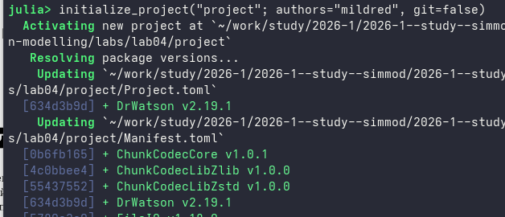

Рисунок 2: Создание каталога для проекта

## Модель

Я выполнила предложенный код для модели src/sir_model.jl. В нем описывается агенты, пространство состояния и другие параметры модели.

## график динамики SIR

Далее я выполнила предлоденный код базового эксперимента.

## Сканирование коэффициента заразности

Я выполнила скрипт sir_scan_beta.jl, который исследует, как изменение базовой заразности (β_und и пропорционально β_det) влияет на эпидемические показатели: пик заболеваемости, долю переболевших, число умерших. Выполняется параметрическое сканирование с несколькими повторными прогонами для учёта стохастичности.

## Многокритериальная оптимизация параметров

- Выполнила код для многокритериальной оптимизации параметров scripts/sir_optimize_parameters.jl.

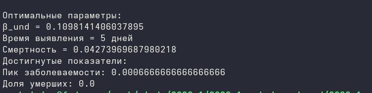

Рисунок 6: Оптимальные параметры

## Сводная визуализация результатов

Выполнила предложенный код для визуализации результатов

## Дополнительные задания

```julia
y = 1/params[:infection_period]
B = params[:β_und][1]
R_0 = B/y

println("базовое репродуктивное число: ", R_0)
```

## Репродуктивное число

[figure not shown]

## Миниальное значение 𝛽

2. Чтобы найти минимальное значение 𝛽, при котором возникает эпидемия, я добавила следующие строка в скрипте sir_scan_beta:

```julia
epidemic_threshold = nothing

for row in eachrow(grouped)
    if row.mean_peak > 0.05
        epidemic_threshold = row.beta
        break
    end
end
```

## Миниальное значение 𝛽

Она равна 0.21 и больше чем теоретический порог в 2 раза (рис. 9)

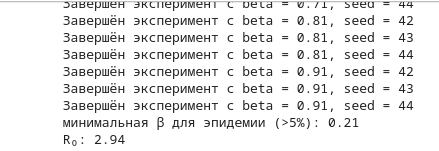

Рисунок 9: Миниальное значение 𝛽

## Эффект гетерогенности

3. Я создала новый скрипт scripts/sir_diff_cities и исползовала три разные значения параметр 𝛽 для всех городов. Сначала я задала значения 0.0, 0.0, 0.1 и получила в ответе (рис. 10)

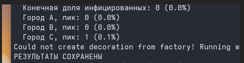

Рисунок 10: Эффект гетерогенности при 𝛽=(0.0, 0.0, 0.1)

## Эффект гетерогенности

Я также построила их графики:

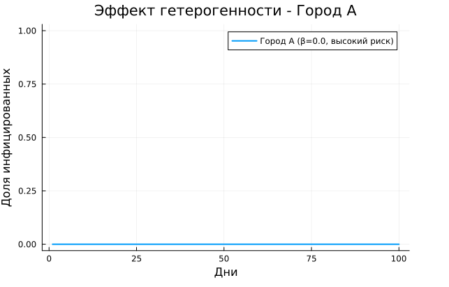

Рисунок 11: графики эффекта гетерогенности при 𝛽=(0.0, 0.0, 0.1) города А

## Эффект гетерогенности

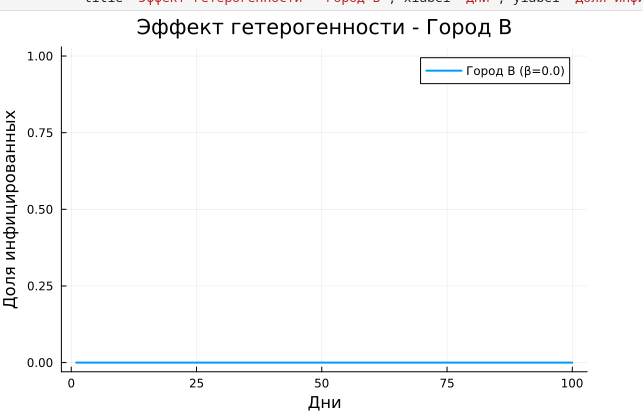

Рисунок 12: графики эффекта гетерогенности при 𝛽=(0.0, 0.0, 0.1)города B

## Эффект гетерогенности

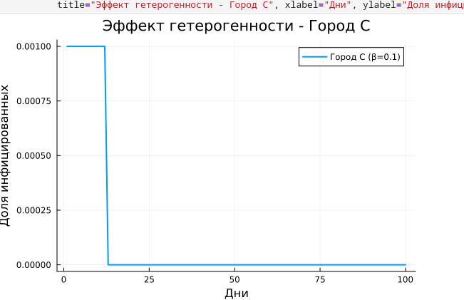

## Эффект гетерогенности

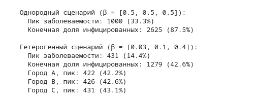

Рисунок 14: Эффект гетерогенности при 𝛽=(0.03, 0.1, 0.4)

## Эффект гетерогенности

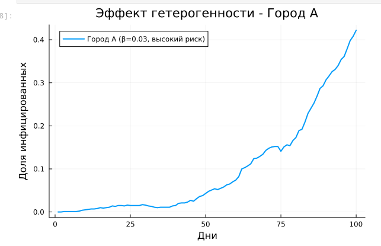

Рисунок 15: График эффекта гетерогенности при 𝛽=(0.03, 0.1, 0.4) города A

## Эффект гетерогенности

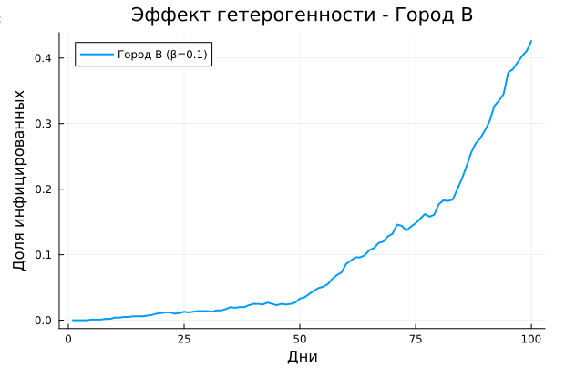

Рисунок 16: График эффекта гетерогенности при 𝛽=(0.03, 0.1, 0.4) города B

## Эффект гетерогенности

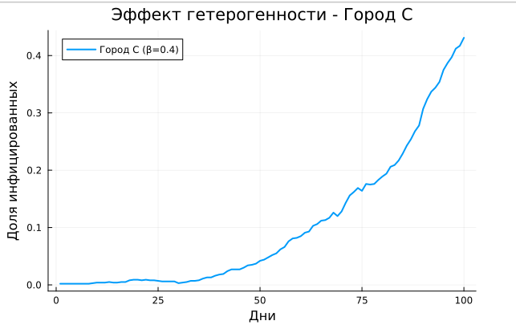

Рисунок 17: График эффекта гетерогенности при 𝛽=(0.03, 0.1, 0.4) города C

## Эффект гетерогенности

в последнем варианте я повысила 𝛽 во втором городе в 6 раз и получила в ответе (рис. 18)

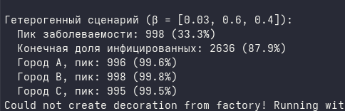

Рисунок 18: Эффект гетерогенности при 𝛽=(0.03, 0.6, 0.4)

## Эффект гетерогенности

Графики получились как в исходном графике:

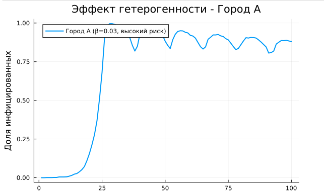

Рисунок 19: График эффекта гетерогенности при 𝛽=(0.03, 0.6, 0.4) города A

## Эффект гетерогенности

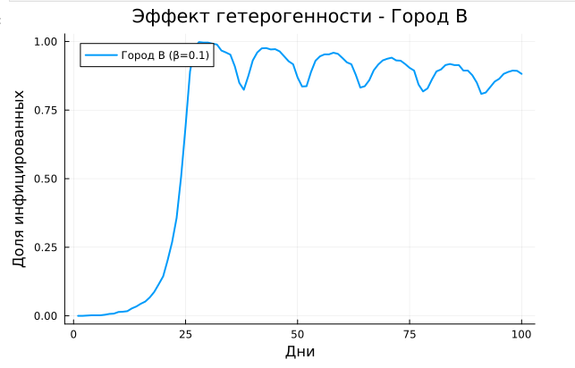

## Эффект гетерогенности

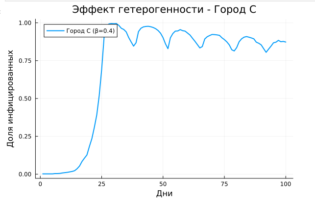

Рисунок 21: График эффекта гетерогенности при 𝛽=(0.03, 0.6, 0.4) города C

## Исследование эффект миграции

4. Запускла скрипт sir_migration_effect и проверила созданный датасет чтобы узнать при какой интенсивности миграции наблюдается минимальное время до пика и заметила ,что при интенсивности 0.0 время до пика минимально.

## Эффект карантина

5. Я добавила возможность закрытия города (обнуление миграции из него) при превышении порога заболеваемости. Получила ,что количество умерших уменьшилось но не сильно

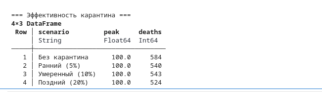

Рисунок 22: Эффект карантина

## Нахождение опитимальных параметров

6. Использовала оптимизацию, чтобы найти параметры, которые минимизируют общее число умерших при сохранении пика заболеваемости ниже 30%.

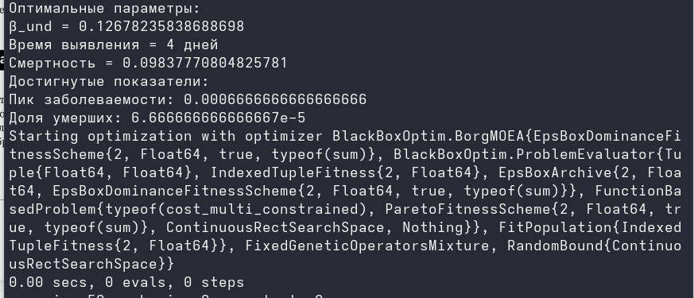

Рисунок 23: Нахождение опитимальных параметров

## Применение опитимальных параметров

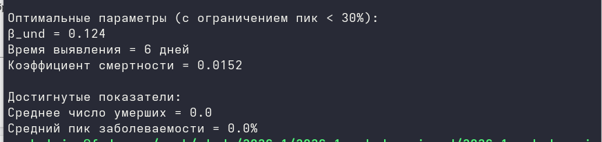

Рисунок 24: Применение опитимальных параметров

# Выводы

При выполнении данной работы я реализовала основных моделей в агентном подходе к имитационному моделированию.